# Time walking

# 1 Description of DataSchema variable

The description of harmonised variable is the following:

- Short name: `t_walks`
- Variable label: `Walking at least 10 min or equivalent by 0.5km during the last 1-2 weeks`
- Variable description: `Walking at least 10 min or equivalent by 0.5km during the last 1-2 weeks`
- Domain: `Lifestyle and health behaviours`
- Value type: `categorical`
- Category coding:

| **Code** | **Category Label** |
| --- | --- |
| 0 | No |
| 1 | Yes |

- Category missings:

| **Code** | **Category Label** |
| --- | --- |
| 991 | CAPI/interviewer error |
| 992 | Impute |
| 993 | Disable to measure |
| 994 | Not attempt/not done |
| 995 | Does not answer |
| 996 | Not applicable |
| 997 | Refuse |
| 998 | Do not know |
| 999 | Missing |

# 2 Data process

## 2.1 Cuba

### 2.1.1 Wave 1

#### 2.1.1.1 Study-specific variable description

| **Name** | `PWALKANY` |
| --- | --- |
| **Label** | `walk of 0.5 kilometre in last month?` |
| **Table name** | `1066-Cuba-Baseline` |
| **Categories:** | `0 = No` `1 = Yes` |
| **Missings:** | `NA` |
| **Description** |  |

PWALKANY

| Sample size | Missing values |
| --- | --- |
| 2813 | 10 |

Category

|  | 0 | 1 |
| --- | --- | --- |
| Frequency | 951.00 | 1852.00 |
| Percentage | 33.81 | 65.84 |

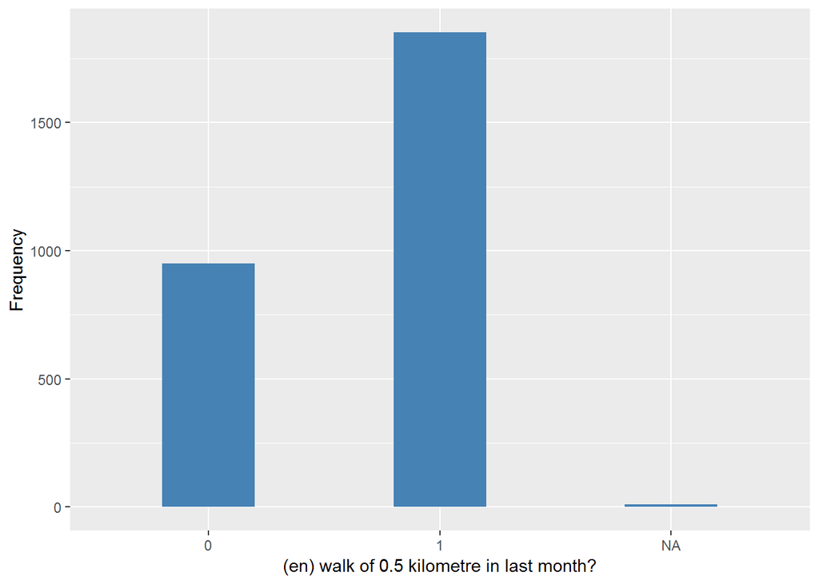

#### 2.1.1.2 Harmonisation algorithm

To compute the harmonize variable from the study-specific variable it has to be recoded as follows:

- `NA into 999`

```r
t1066_ds_cuba_w1 <- tibble(id = t1066_cuba_w1$id)
t1066_ds_cuba_w1$t_walks <- Recode(t1066_cuba_w1$PWALKANY, "NA = '999' ")
t1066_ds_cuba_w1$t_walks <- labelled(t1066_ds_cuba_w1$t_walks, labels = c(Missing = 999,
    Do_not_know = 998, Refuse = 997, Not_applicable = 996, Does_not_answer = 995,
    Not_attempt_not_done = 994, Disable_to_measure = 993, Impute = 992, CAPI_interviewer_error = 991))
```

#### 2.1.1.3 Statistical description of the new harmonised variable

Walking at least 10 min or equivalent by 0.5km during the last 1-2 weeks

| Sample size | Missing values |
| --- | --- |
| 2813 | 10 |

Category

|  | 0 | 1 |
| --- | --- | --- |
| Frequency | 951.00 | 1852.00 |
| Percentage | 33.81 | 65.84 |

Type of missing

|  | 991 | 992 | 993 | 994 | 995 | 996 | 997 | 998 | 999 | NA |
| --- | --- | --- | --- | --- | --- | --- | --- | --- | --- | --- |
| Frequency | 0 | 0 | 0 | 0 | 0 | 0 | 0 | 0 | 10.00 | 0 |
| Percentage | 0 | 0 | 0 | 0 | 0 | 0 | 0 | 0 | 0.36 | 0 |

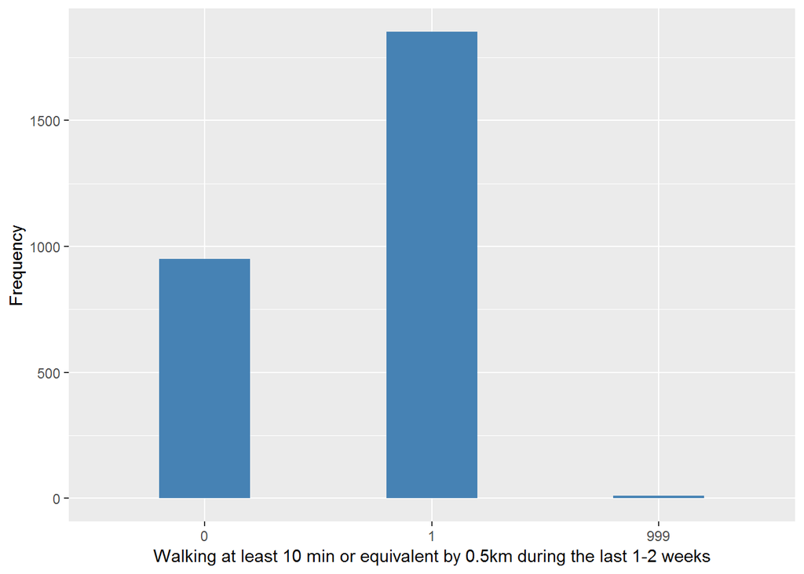

#### 2.1.1.4 Validation

|  | 0->0 | 1->1 | NA->999 |
| --- | --- | --- | --- |
| BeforeH | 951 | 1852 | 10 |
| AfterH | 951 | 1852 | 10 |

### 2.1.2 Wave 2

#### 2.1.2.1 Study-specific variable description

| **Name** | `f_PWALKANY` |
| --- | --- |
| **Label** | `walk of 0.5 kilometre in last month?` |
| **Table name** | `1066-Cuba-Followup` |
| **Categories:** | `0 = No` `1 = Yes` |
| **Missings:** | `NA` |
| **Description** |  |

f_PWALKANY

| Sample size | Missing values |
| --- | --- |
| 2007 | 41 |

Category

|  | 0 | 1 |
| --- | --- | --- |
| Frequency | 851.0 | 1115.00 |
| Percentage | 42.4 | 55.56 |

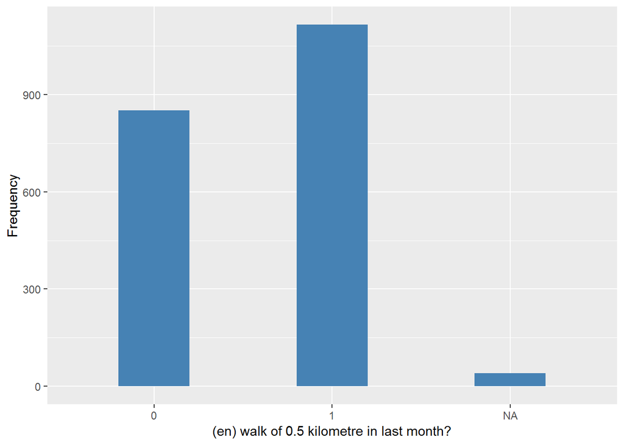

#### 2.1.2.2 Harmonisation algorithm

To compute the harmonize variable from the study-specific variable it has to be recoded as follows:

- `NA into 999`

```r
t1066_ds_cuba_w2 <- tibble(id = t1066_cuba_w2$id)
t1066_ds_cuba_w2$t_walks <- Recode(t1066_cuba_w2$f_PWALKANY, "NA = '999' ")
t1066_ds_cuba_w2$t_walks <- labelled(t1066_ds_cuba_w2$t_walks, labels = c(Missing = 999,
    Do_not_know = 998, Refuse = 997, Not_applicable = 996, Does_not_answer = 995,
    Not_attempt_not_done = 994, Disable_to_measure = 993, Impute = 992, CAPI_interviewer_error = 991))
```

#### 2.1.2.3 Statistical description of the new harmonised variable

Walking at least 10 min or equivalent by 0.5km during the last 1-2 weeks

| Sample size | Missing values |
| --- | --- |
| 2007 | 41 |

Category

|  | 0 | 1 |
| --- | --- | --- |
| Frequency | 851.0 | 1115.00 |
| Percentage | 42.4 | 55.56 |

Type of missing

|  | 991 | 992 | 993 | 994 | 995 | 996 | 997 | 998 | 999 | NA |
| --- | --- | --- | --- | --- | --- | --- | --- | --- | --- | --- |
| Frequency | 0 | 0 | 0 | 0 | 0 | 0 | 0 | 0 | 41.00 | 0 |
| Percentage | 0 | 0 | 0 | 0 | 0 | 0 | 0 | 0 | 2.04 | 0 |

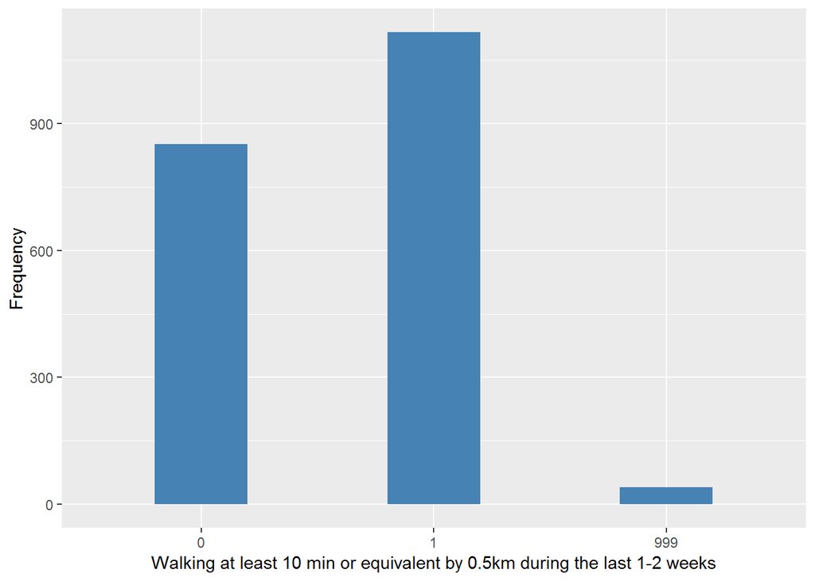

#### 2.1.2.4 Validation

|  | 0->0 | 1->1 | NA->999 |
| --- | --- | --- | --- |
| BeforeH | 851 | 1115 | 41 |
| AfterH | 851 | 1115 | 41 |

## 2.2 India

### 2.2.1 Wave 1

#### 2.2.1.1 Study-specific variable description

| **Name** | `PWALKANY` |
| --- | --- |
| **Label** | `walk of 0.5 kilometre in last month?` |
| **Table name** | `1066-India-Baseline` |
| **Categories:** | `0 = No` `1 = Yes` |
| **Missings:** | `NA` |
| **Description** |  |

PWALKANY

| Sample size | Missing values |
| --- | --- |
| 2004 | 8 |

Category

|  | 0 | 1 |
| --- | --- | --- |
| Frequency | 357.00 | 1639.00 |
| Percentage | 17.81 | 81.79 |

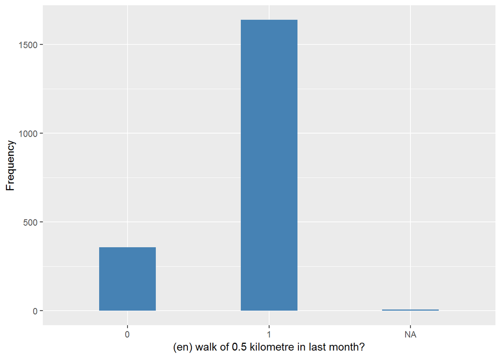

#### 2.2.1.2 Harmonisation algorithm

To compute the harmonize variable from the study-specific variable it has to be recoded as follows:

- `NA into 999`

```r
t1066_ds_india_w1 <- tibble(id = t1066_india_w1$id)
t1066_ds_india_w1$t_walks <- Recode(t1066_india_w1$PWALKANY, "NA = '999' ")
t1066_ds_india_w1$t_walks <- labelled(t1066_ds_india_w1$t_walks, labels = c(Missing = 999,
    Do_not_know = 998, Refuse = 997, Not_applicable = 996, Does_not_answer = 995,
    Not_attempt_not_done = 994, Disable_to_measure = 993, Impute = 992, CAPI_interviewer_error = 991))
```

#### 2.2.1.3 Statistical description of the new harmonised variable

Walking at least 10 min or equivalent by 0.5km during the last 1-2 weeks

| Sample size | Missing values |
| --- | --- |
| 2004 | 8 |

Category

|  | 0 | 1 |
| --- | --- | --- |
| Frequency | 357.00 | 1639.00 |
| Percentage | 17.81 | 81.79 |

Type of missing

|  | 991 | 992 | 993 | 994 | 995 | 996 | 997 | 998 | 999 | NA |
| --- | --- | --- | --- | --- | --- | --- | --- | --- | --- | --- |
| Frequency | 0 | 0 | 0 | 0 | 0 | 0 | 0 | 0 | 8.0 | 0 |
| Percentage | 0 | 0 | 0 | 0 | 0 | 0 | 0 | 0 | 0.4 | 0 |

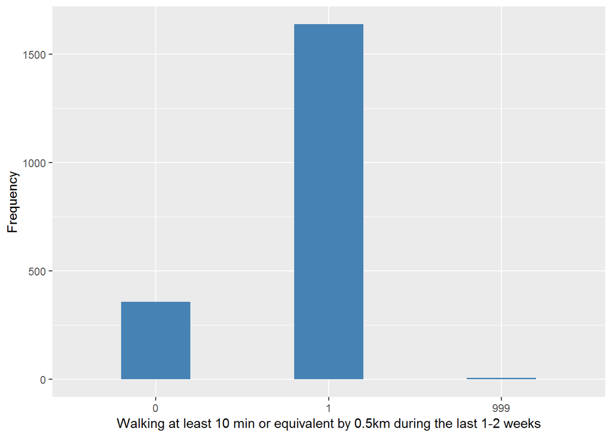

#### 2.2.1.4 Validation

|  | 0->0 | 1->1 | NA->999 |
| --- | --- | --- | --- |
| BeforeH | 357 | 1639 | 8 |
| AfterH | 357 | 1639 | 8 |

## 2.3 Urban China

### 2.3.1 Wave 1

#### 2.3.1.1 Study-specific variable description

| **Name** | `PWALKANY` |
| --- | --- |
| **Label** | `walk of 0.5 kilometre in last month?` |
| **Table name** | `1066-UrbanChina-Baseline` |
| **Categories:** | `0 = No` `1 = Yes` |
| **Missings:** |  |
| **Description** |  |

PWALKANY

| Sample size | Missing values |
| --- | --- |
| 1160 | 0 |

Category

|  | 0 | 1 |
| --- | --- | --- |
| Frequency | 209.00 | 951.00 |
| Percentage | 18.02 | 81.98 |

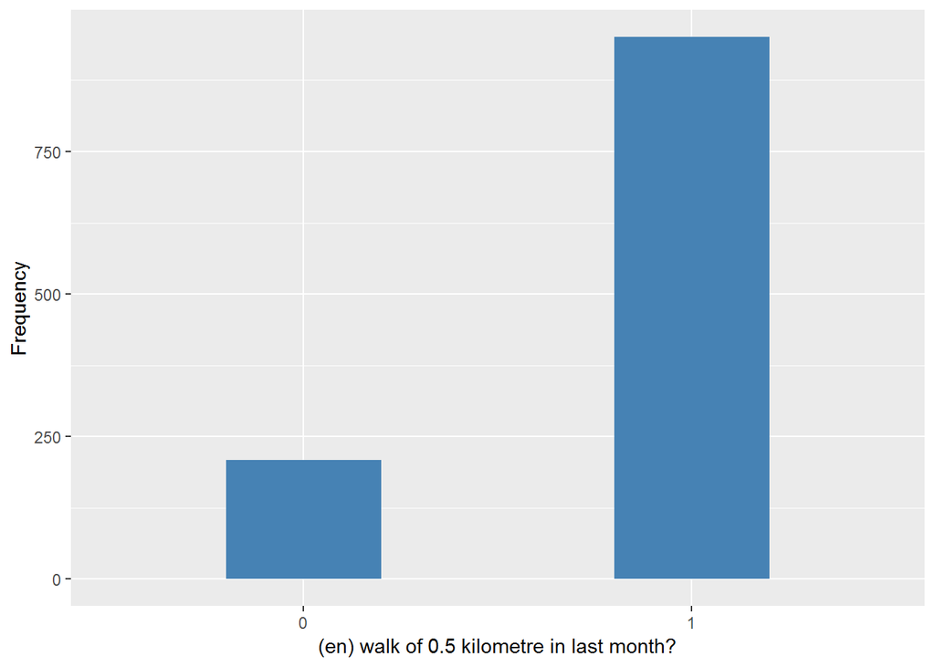

#### 2.3.1.2 Harmonisation algorithm

To compute the harmonize variable from the study-specific variable it has to be recoded as follows:

- `NA into 999`

```r
t1066_ds_UCh_w1 <- tibble(id = t1066_UCh_w1$id)
t1066_ds_UCh_w1$t_walks <- Recode(t1066_UCh_w1$PWALKANY, "NA = '999' ")
t1066_ds_UCh_w1$t_walks <- labelled(t1066_ds_UCh_w1$t_walks, labels = c(Missing = 999,
    Do_not_know = 998, Refuse = 997, Not_applicable = 996, Does_not_answer = 995,
    Not_attempt_not_done = 994, Disable_to_measure = 993, Impute = 992, CAPI_interviewer_error = 991))
```

#### 2.3.1.3 Statistical description of the new harmonised variable

Walking at least 10 min or equivalent by 0.5km during the last 1-2 weeks

| Sample size | Missing values |
| --- | --- |
| 1160 | 0 |

Category

|  | 0 | 1 |
| --- | --- | --- |
| Frequency | 209.00 | 951.00 |
| Percentage | 18.02 | 81.98 |

Type of missing

|  | 991 | 992 | 993 | 994 | 995 | 996 | 997 | 998 | 999 | NA |
| --- | --- | --- | --- | --- | --- | --- | --- | --- | --- | --- |
| Frequency | 0 | 0 | 0 | 0 | 0 | 0 | 0 | 0 | 0 | 0 |
| Percentage | 0 | 0 | 0 | 0 | 0 | 0 | 0 | 0 | 0 | 0 |

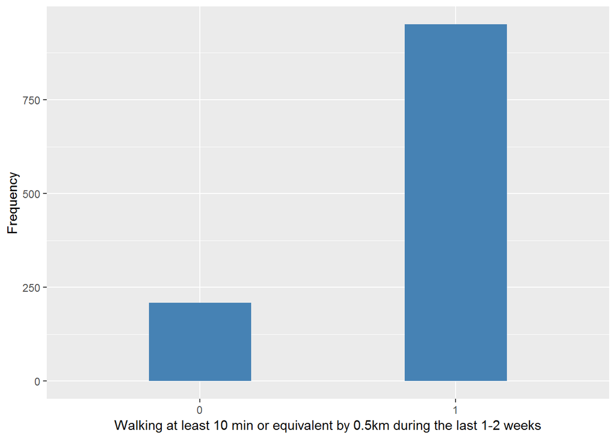

#### 2.3.1.4 Validation

|  | 0->0 | 1->1 |
| --- | --- | --- |
| BeforeH | 209 | 951 |
| AfterH | 209 | 951 |

### 2.3.2 Wave 2

#### 2.3.2.1 Study-specific variable description

| **Name** | `f_PWALKANY` |
| --- | --- |
| **Label** | `walk of 0.5 kilometre in last month?` |
| **Table name** | `1066-UrbanChina-Followup` |
| **Categories:** | `0 = No` `1 = Yes` |
| **Missings:** |  |
| **Description** |  |

f_PWALKANY

| Sample size | Missing values |
| --- | --- |
| 741 | 0 |

Category

|  | 0 | 1 |
| --- | --- | --- |
| Frequency | 162.00 | 579.00 |
| Percentage | 21.86 | 78.14 |

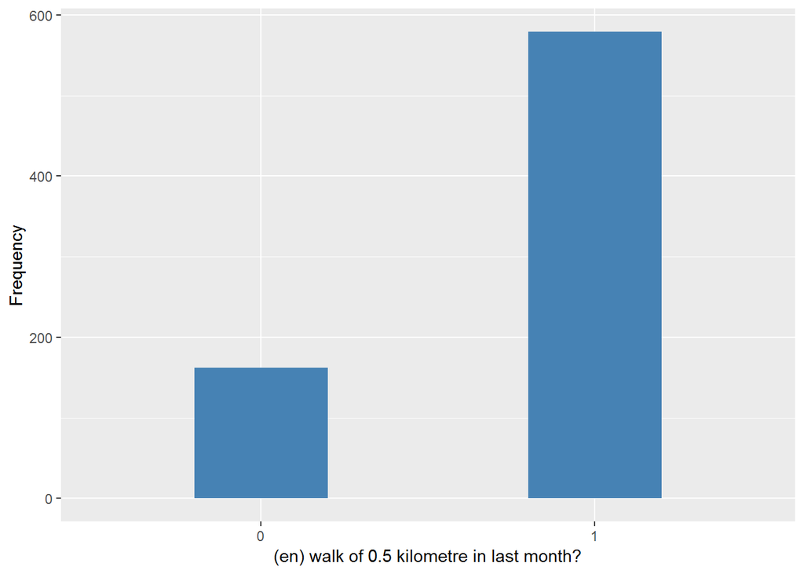

#### 2.3.2.2 Harmonisation algorithm

To compute the harmonize variable from the study-specific variable it has to be recoded as follows

- `NA into 999`

```r
t1066_ds_UCh_w2 <- tibble(id = t1066_UCh_w2$id)
t1066_ds_UCh_w2$t_walks <- Recode(t1066_UCh_w2$f_PWALKANY, "NA = '999' ")
t1066_ds_UCh_w2$t_walks <- labelled(t1066_ds_UCh_w2$t_walks, labels = c(Missing = 999,
    Do_not_know = 998, Refuse = 997, Not_applicable = 996, Does_not_answer = 995,
    Not_attempt_not_done = 994, Disable_to_measure = 993, Impute = 992, CAPI_interviewer_error = 991))
```

#### 2.3.2.3 Statistical description of the new harmonised variable

Walking at least 10 min or equivalent by 0.5km during the last 1-2 weeks

| Sample size | Missing values |
| --- | --- |
| 741 | 0 |

Category

|  | 0 | 1 |
| --- | --- | --- |
| Frequency | 162.00 | 579.00 |
| Percentage | 21.86 | 78.14 |

Type of missing

|  | 991 | 992 | 993 | 994 | 995 | 996 | 997 | 998 | 999 | NA |
| --- | --- | --- | --- | --- | --- | --- | --- | --- | --- | --- |
| Frequency | 0 | 0 | 0 | 0 | 0 | 0 | 0 | 0 | 0 | 0 |
| Percentage | 0 | 0 | 0 | 0 | 0 | 0 | 0 | 0 | 0 | 0 |

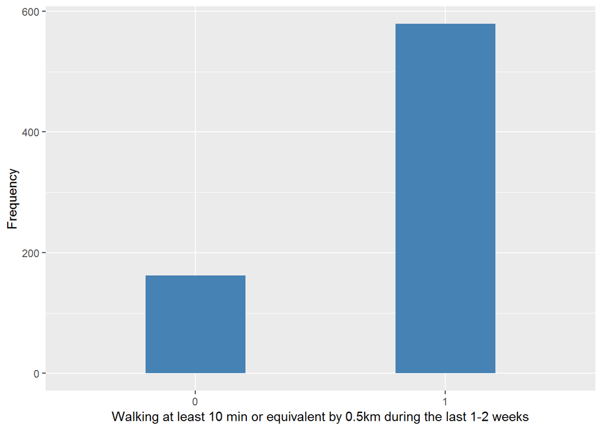

#### 2.3.2.4 Validation

|  | 0->0 | 1->1 |
| --- | --- | --- |
| BeforeH | 162 | 579 |
| AfterH | 162 | 579 |

## 2.4 Rural China

### 2.4.1 Wave 1

#### 2.4.1.1 Study-specific variable description

| **Name** | `PWALKANY` |
| --- | --- |
| **Label** | `walk of 0.5 kilometre in last month?` |
| **Table name** | `1066-RuralChina-Baseline` |
| **Categories:** | `0 = No` `1 = Yes` |
| **Missings:** | `NA` |
| **Description** |  |

PWALKANY

| Sample size | Missing values |
| --- | --- |
| 1002 | 5 |

Category

|  | 0 | 1 |
| --- | --- | --- |
| Frequency | 384.00 | 613.00 |
| Percentage | 38.32 | 61.18 |

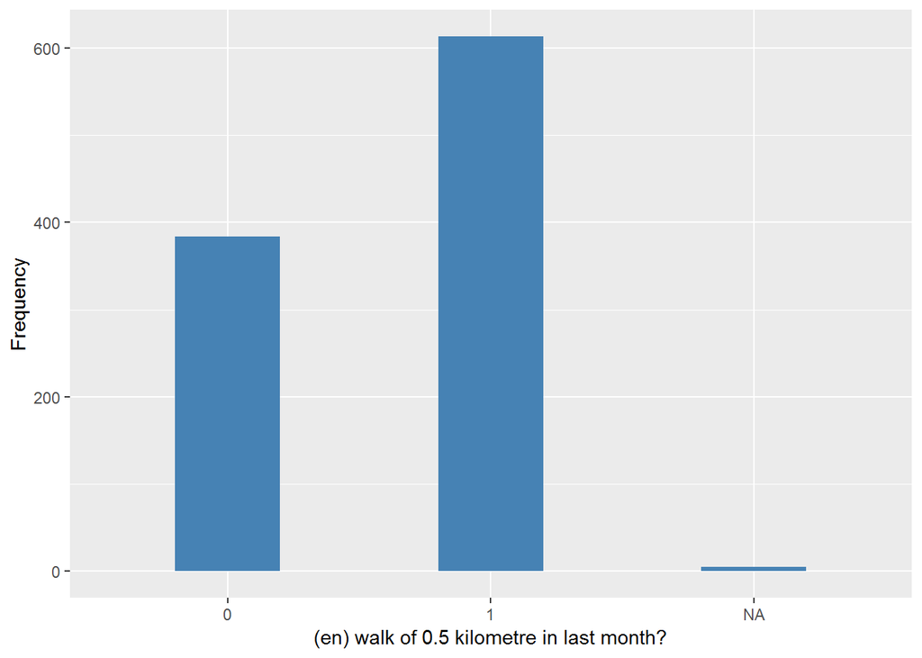

#### 2.4.1.2 Harmonisation algorithm

To compute the harmonize variable from the study-specific variable it has to be recoded as follows:

- `NA into 999`

```r
t1066_ds_RCh_w1 <- tibble(id = t1066_RCh_w1$id)
t1066_ds_RCh_w1$t_walks <- Recode(t1066_RCh_w1$PWALKANY, "NA = '999' ")
t1066_ds_RCh_w1$t_walks <- labelled(t1066_ds_RCh_w1$t_walks, labels = c(Missing = 999,
    Do_not_know = 998, Refuse = 997, Not_applicable = 996, Does_not_answer = 995,
    Not_attempt_not_done = 994, Disable_to_measure = 993, Impute = 992, CAPI_interviewer_error = 991))
```

#### 2.4.1.3 Statistical description of the new harmonised variable

Walking at least 10 min or equivalent by 0.5km during the last 1-2 weeks

| Sample size | Missing values |
| --- | --- |
| 1002 | 5 |

Category

|  | 0 | 1 |
| --- | --- | --- |
| Frequency | 384.00 | 613.00 |
| Percentage | 38.32 | 61.18 |

Type of missing

|  | 991 | 992 | 993 | 994 | 995 | 996 | 997 | 998 | 999 | NA |
| --- | --- | --- | --- | --- | --- | --- | --- | --- | --- | --- |
| Frequency | 0 | 0 | 0 | 0 | 0 | 0 | 0 | 0 | 5.0 | 0 |
| Percentage | 0 | 0 | 0 | 0 | 0 | 0 | 0 | 0 | 0.5 | 0 |

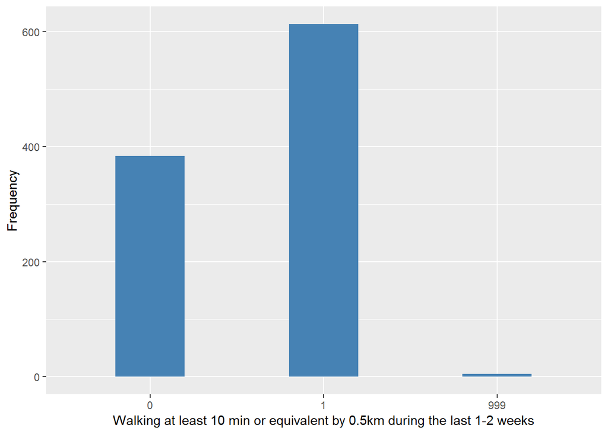

#### 2.4.1.4 Validation

|  | 0->0 | 1->1 | NA->999 |
| --- | --- | --- | --- |
| BeforeH | 384 | 613 | 5 |
| AfterH | 384 | 613 | 5 |

### 2.4.2 Wave 2

#### 2.4.2.1 Study-specific variable description

| **Name** | `f_PWALKANY` |
| --- | --- |
| **Label** | `walk of 0.5 kilometre in last month?` |
| **Table name** | `1066-RuralChina-Followup` |
| **Categories:** | `0 = No` `1 = Yes` |
| **Missings:** |  |
| **Description** |  |

f_PWALKANY

| Sample size | Missing values |
| --- | --- |
| 711 | 0 |

Category

|  | 0 | 1 |
| --- | --- | --- |
| Frequency | 188.00 | 523.00 |
| Percentage | 26.44 | 73.56 |

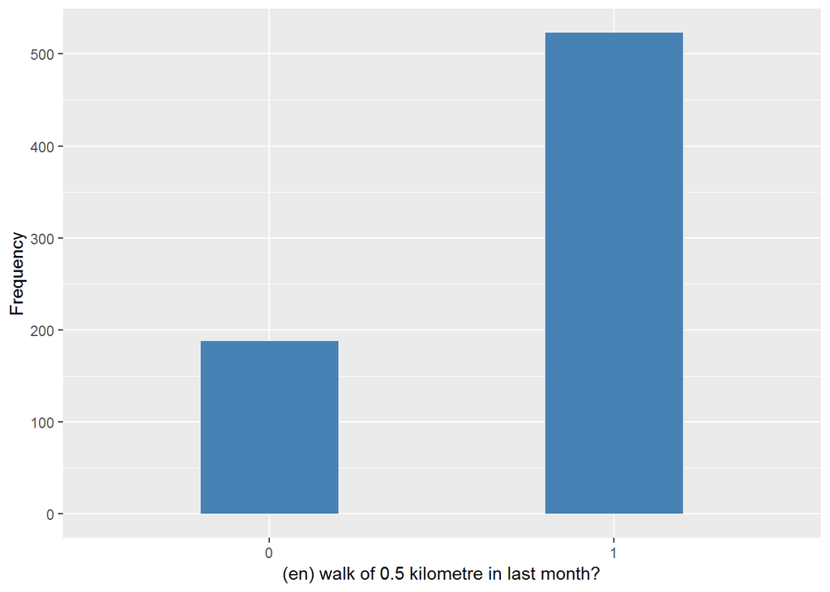

#### 2.4.2.2 Harmonisation algorithm

To compute the harmonize variable from the study-specific variable it has to be recoded as follows:

- `NA into 999`

```r
t1066_ds_RCh_w2 <- tibble(id = t1066_RCh_w2$id)
t1066_ds_RCh_w2$t_walks <- Recode(t1066_RCh_w2$f_PWALKANY, "NA = '999' ")
t1066_ds_RCh_w2$t_walks <- labelled(t1066_ds_RCh_w2$t_walks, labels = c(Missing = 999,
    Do_not_know = 998, Refuse = 997, Not_applicable = 996, Does_not_answer = 995,
    Not_attempt_not_done = 994, Disable_to_measure = 993, Impute = 992, CAPI_interviewer_error = 991))
```

#### 2.4.2.3 Statistical description of the new harmonised variable

Walking at least 10 min or equivalent by 0.5km during the last 1-2 weeks

| Sample size | Missing values |
| --- | --- |
| 711 | 0 |

Category

|  | 0 | 1 |
| --- | --- | --- |
| Frequency | 188.00 | 523.00 |
| Percentage | 26.44 | 73.56 |

Type of missing

|  | 991 | 992 | 993 | 994 | 995 | 996 | 997 | 998 | 999 | NA |
| --- | --- | --- | --- | --- | --- | --- | --- | --- | --- | --- |
| Frequency | 0 | 0 | 0 | 0 | 0 | 0 | 0 | 0 | 0 | 0 |
| Percentage | 0 | 0 | 0 | 0 | 0 | 0 | 0 | 0 | 0 | 0 |

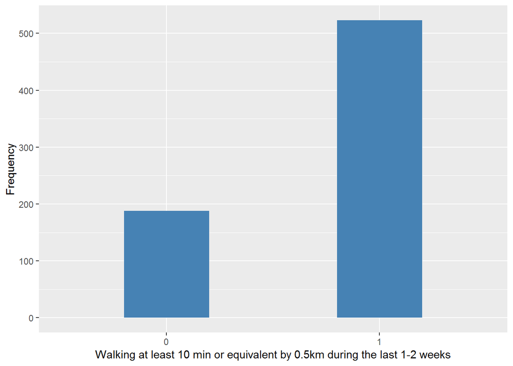

#### 2.4.2.4 Validation

[output not shown]

## 2.5 Dominican Republic

### 2.5.1 Wave 1

#### 2.5.1.1 Study-specific variable description

| **Name** | `PWALKANY` |
| --- | --- |
| **Label** | `walk of 0.5 kilometre in last month?` |
| **Table name** | `1066-DominicanRepublic-Baseline` |
| **Categories:** | `0 = No` `1 = Yes` |
| **Missings:** | `NA` |
| **Description** |  |

PWALKANY

| Sample size | Missing values |
| --- | --- |
| 2011 | 12 |

Category

|  | 0 | 1 |
| --- | --- | --- |
| Frequency | 745.00 | 1254.00 |
| Percentage | 37.05 | 62.36 |

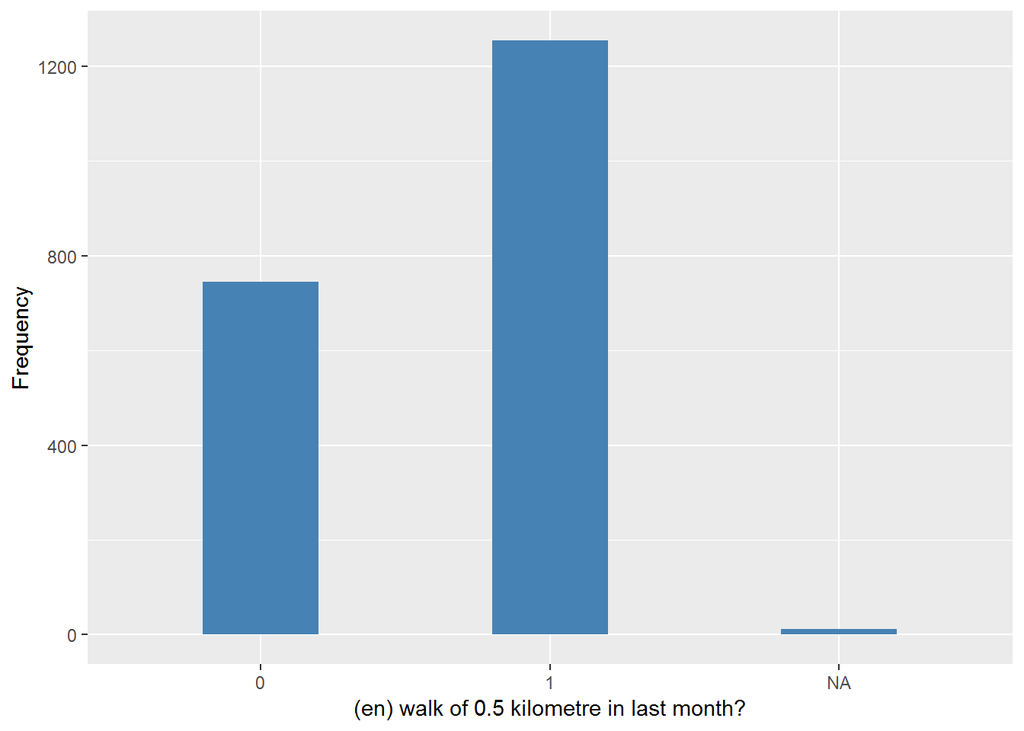

#### 2.5.1.2 Harmonisation algorithm

To compute the harmonize variable from the study-specific variable it has to be recoded as follows:

- `NA into 999`

```r
t1066_ds_DR_w1 <- tibble(id = t1066_DR_w1$id)
t1066_ds_DR_w1$t_walks <- Recode(t1066_DR_w1$PWALKANY, "NA = '999' ")
t1066_ds_DR_w1$t_walks <- labelled(t1066_ds_DR_w1$t_walks, labels = c(Missing = 999,
    Do_not_know = 998, Refuse = 997, Not_applicable = 996, Does_not_answer = 995,
    Not_attempt_not_done = 994, Disable_to_measure = 993, Impute = 992, CAPI_interviewer_error = 991))
```

#### 2.5.1.3 Statistical description of the new harmonised variable

Walking at least 10 min or equivalent by 0.5km during the last 1-2 weeks

| Sample size | Missing values |
| --- | --- |
| 2011 | 12 |

Category

|  | 0 | 1 |
| --- | --- | --- |
| Frequency | 745.00 | 1254.00 |
| Percentage | 37.05 | 62.36 |

Type of missing

|  | 991 | 992 | 993 | 994 | 995 | 996 | 997 | 998 | 999 | NA |
| --- | --- | --- | --- | --- | --- | --- | --- | --- | --- | --- |
| Frequency | 0 | 0 | 0 | 0 | 0 | 0 | 0 | 0 | 12.0 | 0 |
| Percentage | 0 | 0 | 0 | 0 | 0 | 0 | 0 | 0 | 0.6 | 0 |

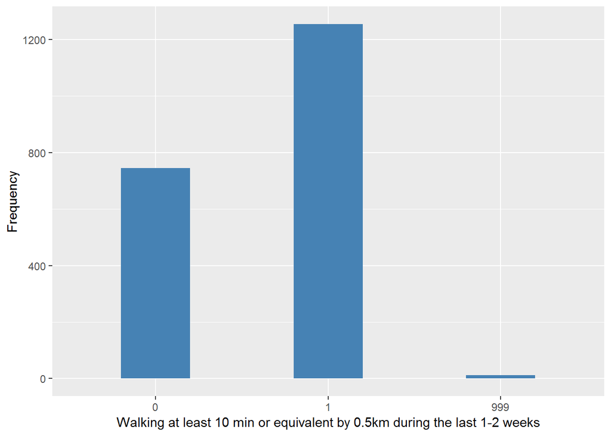

#### 2.5.1.4 Validation

|  | 0->0 | 1->1 | NA->999 |
| --- | --- | --- | --- |
| BeforeH | 745 | 1254 | 12 |
| AfterH | 745 | 1254 | 12 |

### 2.5.2 Wave 2

#### 2.5.2.1 Study-specific variable description

| **Name** | `f_PWALKANY` |
| --- | --- |
| **Label** | `walk of 0.5 kilometre in last month?` |
| **Table name** | `1066-DominicanRepublic-Followup` |
| **Categories:** | `0 = No` `1 = Yes` |
| **Missings:** | `NA` |
| **Description** |  |

f_PWALKANY

| Sample size | Missing values |
| --- | --- |
| 1197 | 11 |

Category

|  | 0 | 1 |
| --- | --- | --- |
| Frequency | 553.0 | 633.00 |
| Percentage | 46.2 | 52.88 |

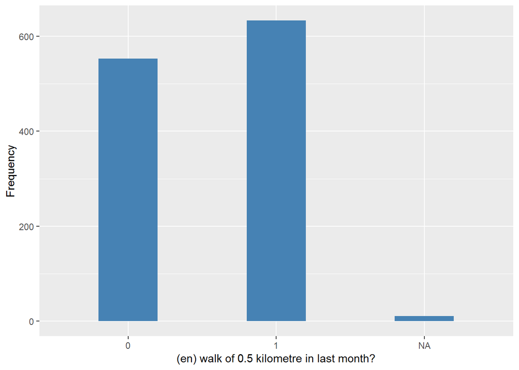

#### 2.5.2.2 Harmonisation algorithm

To compute the harmonize variable from the study-specific variable it has to be recoded as follows:

- `NA into 999`

```r
t1066_ds_DR_w2 <- tibble(id = t1066_DR_w2$id)
t1066_ds_DR_w2$t_walks <- Recode(t1066_DR_w2$f_PWALKANY, "NA = '999' ")
t1066_ds_DR_w2$t_walks <- labelled(t1066_ds_DR_w2$t_walks, labels = c(Missing = 999,
    Do_not_know = 998, Refuse = 997, Not_applicable = 996, Does_not_answer = 995,
    Not_attempt_not_done = 994, Disable_to_measure = 993, Impute = 992, CAPI_interviewer_error = 991))
```

#### 2.5.2.3 Statistical description of the new harmonised variable

Walking at least 10 min or equivalent by 0.5km during the last 1-2 weeks

| Sample size | Missing values |
| --- | --- |
| 1197 | 11 |

Category

|  | 0 | 1 |
| --- | --- | --- |
| Frequency | 553.0 | 633.00 |
| Percentage | 46.2 | 52.88 |

Type of missing

|  | 991 | 992 | 993 | 994 | 995 | 996 | 997 | 998 | 999 | NA |
| --- | --- | --- | --- | --- | --- | --- | --- | --- | --- | --- |
| Frequency | 0 | 0 | 0 | 0 | 0 | 0 | 0 | 0 | 11.00 | 0 |
| Percentage | 0 | 0 | 0 | 0 | 0 | 0 | 0 | 0 | 0.92 | 0 |

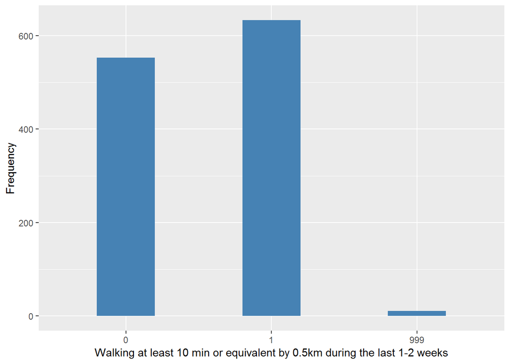

#### 2.5.2.4 Validation

|  | 0->0 | 1->1 | NA->999 |
| --- | --- | --- | --- |
| BeforeH | 553 | 633 | 11 |
| AfterH | 553 | 633 | 11 |

## 2.6 Venezuela

### 2.6.1 Wave 1

#### 2.6.1.1 Study-specific variable description

| **Name** | `PWALKANY` |
| --- | --- |
| **Label** | `walk of 0.5 kilometre in last month?` |
| **Table name** | `1066-Venezuela-Baseline` |
| **Categories:** | `0 = No` `1 = Yes` |
| **Missings:** | `NA` |
| **Description** |  |

PWALKANY

| Sample size | Missing values |
| --- | --- |
| 1965 | 70 |

Category

|  | 0 | 1 |
| --- | --- | --- |
| Frequency | 549.00 | 1346.0 |
| Percentage | 27.94 | 68.5 |

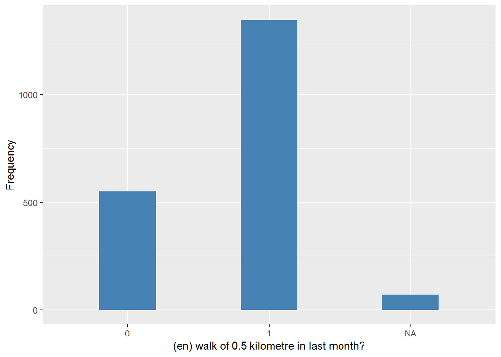

#### 2.6.1.2 Harmonisation algorithm

To compute the harmonize variable from the study-specific variable it has to be recoded as follows:

- `NA into 999`

```r
t1066_ds_Ven_w1 <- tibble(id = t1066_Ven_w1$id)
t1066_ds_Ven_w1$t_walks <- Recode(t1066_Ven_w1$PWALKANY, "NA = '999' ")
t1066_ds_Ven_w1$t_walks <- labelled(t1066_ds_Ven_w1$t_walks, labels = c(Missing = 999,
    Do_not_know = 998, Refuse = 997, Not_applicable = 996, Does_not_answer = 995,
    Not_attempt_not_done = 994, Disable_to_measure = 993, Impute = 992, CAPI_interviewer_error = 991))
```

#### 2.6.1.3 Statistical description of the new harmonised variable

Walking at least 10 min or equivalent by 0.5km during the last 1-2 weeks

| Sample size | Missing values |
| --- | --- |
| 1965 | 70 |

Category

|  | 0 | 1 |
| --- | --- | --- |
| Frequency | 549.00 | 1346.0 |
| Percentage | 27.94 | 68.5 |

Type of missing

|  | 991 | 992 | 993 | 994 | 995 | 996 | 997 | 998 | 999 | NA |
| --- | --- | --- | --- | --- | --- | --- | --- | --- | --- | --- |
| Frequency | 0 | 0 | 0 | 0 | 0 | 0 | 0 | 0 | 70.00 | 0 |
| Percentage | 0 | 0 | 0 | 0 | 0 | 0 | 0 | 0 | 3.56 | 0 |

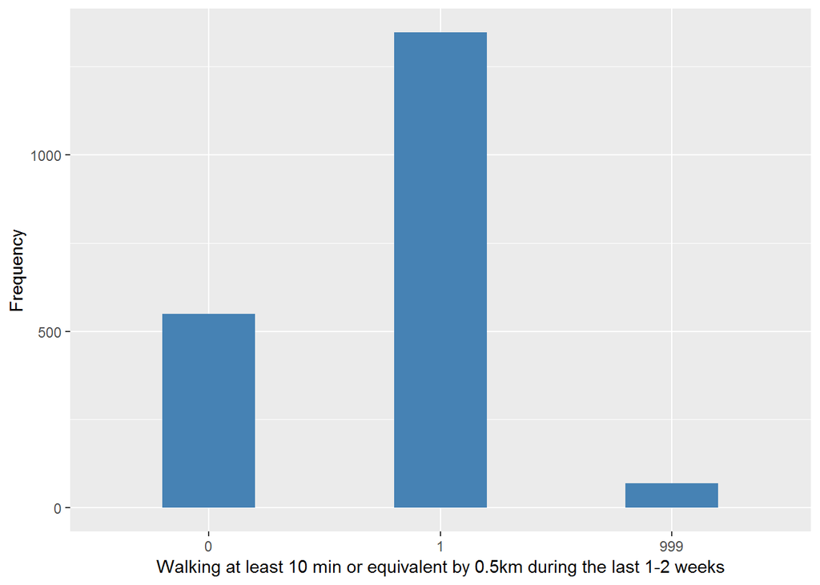

#### 2.6.1.4 Validation

|  | 0->0 | 1->1 | NA->999 |
| --- | --- | --- | --- |
| BeforeH | 549 | 1346 | 70 |
| AfterH | 549 | 1346 | 70 |

### 2.6.2 Wave 2

#### 2.6.2.1 Study-specific variable description

| **Name** | `f_PWALKANY` |
| --- | --- |
| **Label** | `walk of 0.5 kilometre in last month?` |
| **Table name** | `1066-Venezuela-Followup` |
| **Categories:** | `0 = No` `1 = Yes` |
| **Missings:** | `NA` |
| **Description** |  |

f_PWALKANY

| Sample size | Missing values |
| --- | --- |
| 1257 | 8 |

Category

|  | 0 | 1 |
| --- | --- | --- |
| Frequency | 456.00 | 793.00 |
| Percentage | 36.28 | 63.09 |

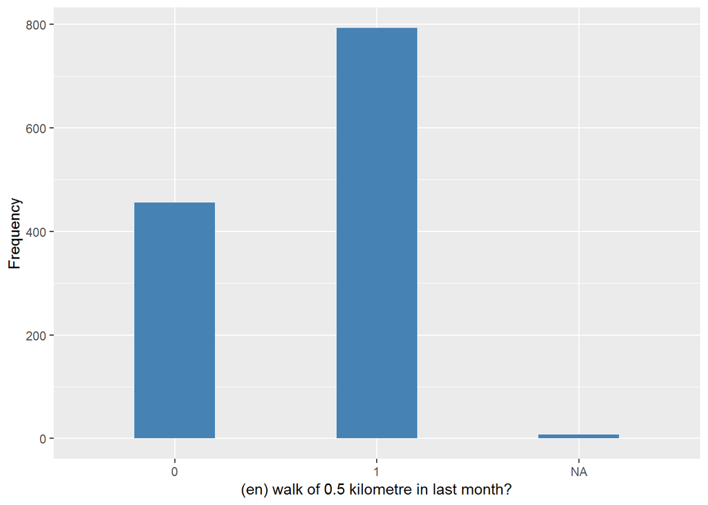

#### 2.6.2.2 Harmonisation algorithm

To compute the harmonize variable from the study-specific variable it has to be recoded as follows:

- `NA into 999`

```r
t1066_ds_Ven_w2 <- tibble(id = t1066_Ven_w2$id)
t1066_ds_Ven_w2$t_walks <- Recode(t1066_Ven_w2$f_PWALKANY, "NA = '999' ")
t1066_ds_Ven_w2$t_walks <- labelled(t1066_ds_Ven_w2$t_walks, labels = c(Missing = 999,
    Do_not_know = 998, Refuse = 997, Not_applicable = 996, Does_not_answer = 995,
    Not_attempt_not_done = 994, Disable_to_measure = 993, Impute = 992, CAPI_interviewer_error = 991))
```

#### 2.6.2.3 Statistical description of the new harmonised variable

Walking at least 10 min or equivalent by 0.5km during the last 1-2 weeks

| Sample size | Missing values |
| --- | --- |
| 1257 | 8 |

Category

|  | 0 | 1 |
| --- | --- | --- |
| Frequency | 456.00 | 793.00 |
| Percentage | 36.28 | 63.09 |

Type of missing

|  | 991 | 992 | 993 | 994 | 995 | 996 | 997 | 998 | 999 | NA |
| --- | --- | --- | --- | --- | --- | --- | --- | --- | --- | --- |
| Frequency | 0 | 0 | 0 | 0 | 0 | 0 | 0 | 0 | 8.00 | 0 |
| Percentage | 0 | 0 | 0 | 0 | 0 | 0 | 0 | 0 | 0.64 | 0 |

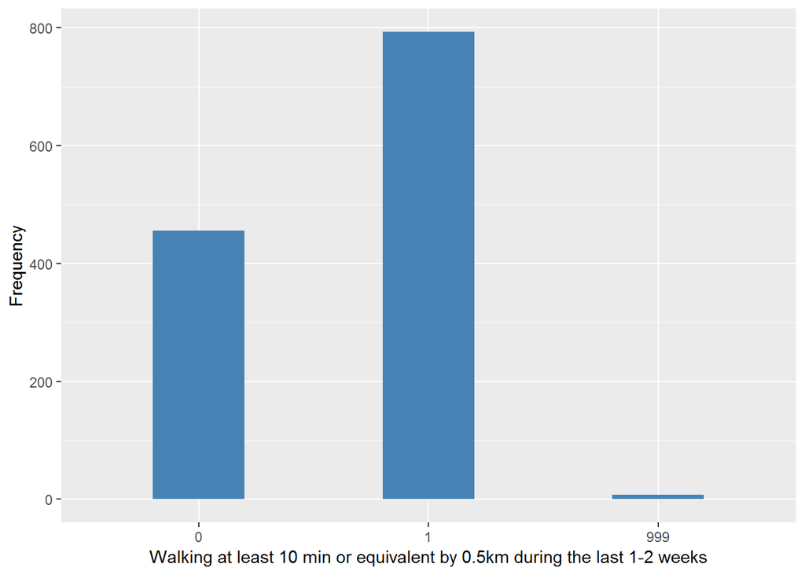

#### 2.6.2.4 Validation

|  | 0->0 | 1->1 | NA->999 |
| --- | --- | --- | --- |
| BeforeH | 456 | 793 | 8 |
| AfterH | 456 | 793 | 8 |

## 2.7 Urban Peru

### 2.7.1 Wave 1

#### 2.7.1.1 Study-specific variable description

| **Name** | `PWALKANY` |
| --- | --- |
| **Label** | `walk of 0.5 kilometre in last month?` |
| **Table name** | `1066-UrbanPeru-Baseline` |
| **Categories:** | `0 = No` `1 = Yes` |
| **Missings:** | `NA` |
| **Description** |  |

PWALKANY

| Sample size | Missing values |
| --- | --- |
| 1381 | 8 |

Category

|  | 0 | 1 |
| --- | --- | --- |
| Frequency | 684.00 | 689.00 |
| Percentage | 49.53 | 49.89 |

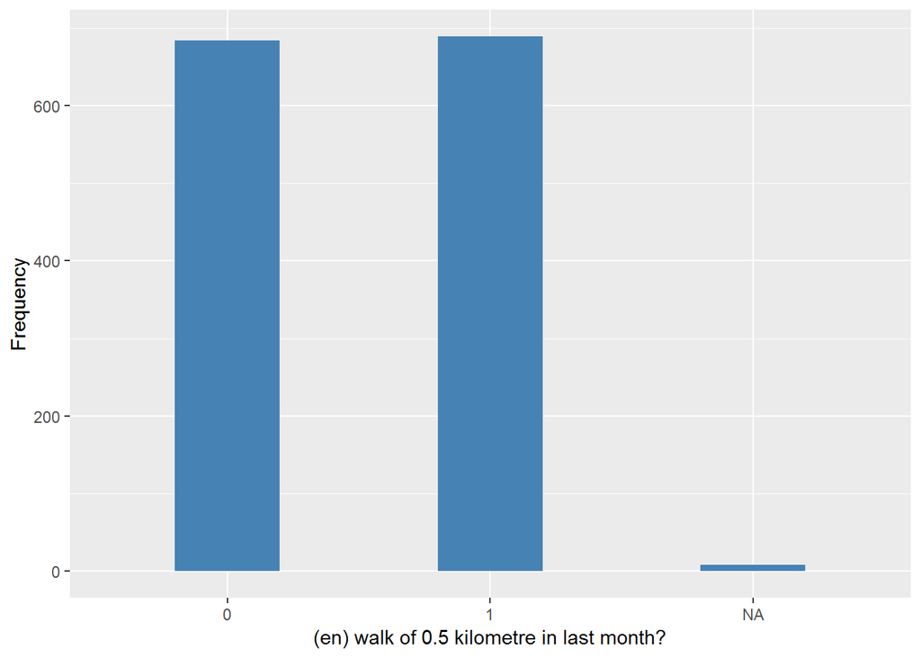

#### 2.7.1.2 Harmonisation algorithm

To compute the harmonize variable from the study-specific variable it has to be recoded as follows:

- `NA into 999`

```r
t1066_ds_UP_w1 <- tibble(id = t1066_UP_w1$id)
t1066_ds_UP_w1$t_walks <- Recode(t1066_UP_w1$PWALKANY, "NA = '999' ")
t1066_ds_UP_w1$t_walks <- labelled(t1066_ds_UP_w1$t_walks, labels = c(Missing = 999,
    Do_not_know = 998, Refuse = 997, Not_applicable = 996, Does_not_answer = 995,
    Not_attempt_not_done = 994, Disable_to_measure = 993, Impute = 992, CAPI_interviewer_error = 991))
```

#### 2.7.1.3 Statistical description of the new harmonised variable

Walking at least 10 min or equivalent by 0.5km during the last 1-2 weeks

| Sample size | Missing values |
| --- | --- |
| 1381 | 8 |

Category

|  | 0 | 1 |
| --- | --- | --- |
| Frequency | 684.00 | 689.00 |
| Percentage | 49.53 | 49.89 |

Type of missing

|  | 991 | 992 | 993 | 994 | 995 | 996 | 997 | 998 | 999 | NA |
| --- | --- | --- | --- | --- | --- | --- | --- | --- | --- | --- |
| Frequency | 0 | 0 | 0 | 0 | 0 | 0 | 0 | 0 | 8.00 | 0 |
| Percentage | 0 | 0 | 0 | 0 | 0 | 0 | 0 | 0 | 0.58 | 0 |

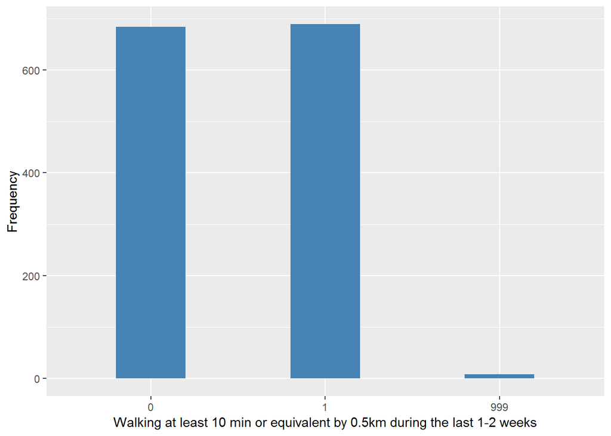

#### 2.7.1.4 Validation

|  | 0->0 | 1->1 | NA->999 |
| --- | --- | --- | --- |
| BeforeH | 684 | 689 | 8 |
| AfterH | 684 | 689 | 8 |

### 2.7.2 Wave 2

#### 2.7.2.1 Study-specific variable description

| **Name** | `f_PWALKANY` |
| --- | --- |
| **Label** | `walk of 0.5 kilometre in last month?` |
| **Table name** | `1066-UrbanPeru-Followup` |
| **Categories:** | `0 = No` `1 = Yes` |
| **Missings:** |  |
| **Description** |  |

f_PWALKANY

| Sample size | Missing values |
| --- | --- |
| 890 | 0 |

Category

|  | 0 | 1 |
| --- | --- | --- |
| Frequency | 489.00 | 401.00 |
| Percentage | 54.94 | 45.06 |

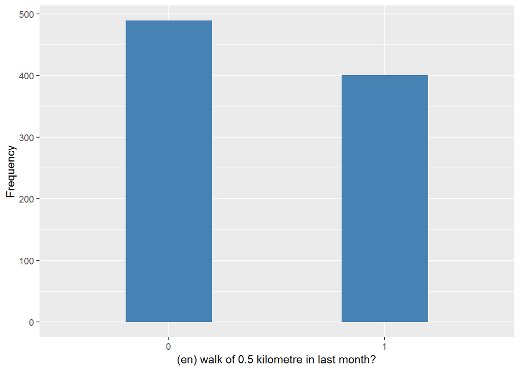

#### 2.7.2.2 Harmonisation algorithm

To compute the harmonize variable from the study-specific variable it has to be recoded as follows:

- `NA into 999`

```r
t1066_ds_UP_w2 <- tibble(id = t1066_UP_w2$id)
t1066_ds_UP_w2$t_walks <- Recode(t1066_UP_w2$f_PWALKANY, "NA = '999' ")
t1066_ds_UP_w2$t_walks <- labelled(t1066_ds_UP_w2$t_walks, labels = c(Missing = 999,
    Do_not_know = 998, Refuse = 997, Not_applicable = 996, Does_not_answer = 995,
    Not_attempt_not_done = 994, Disable_to_measure = 993, Impute = 992, CAPI_interviewer_error = 991))
```

#### 2.7.2.3 Statistical description of the new harmonised variable

Walking at least 10 min or equivalent by 0.5km during the last 1-2 weeks

| Sample size | Missing values |
| --- | --- |
| 890 | 0 |

Category

|  | 0 | 1 |
| --- | --- | --- |
| Frequency | 489.00 | 401.00 |
| Percentage | 54.94 | 45.06 |

Type of missing

|  | 991 | 992 | 993 | 994 | 995 | 996 | 997 | 998 | 999 | NA |
| --- | --- | --- | --- | --- | --- | --- | --- | --- | --- | --- |
| Frequency | 0 | 0 | 0 | 0 | 0 | 0 | 0 | 0 | 0 | 0 |
| Percentage | 0 | 0 | 0 | 0 | 0 | 0 | 0 | 0 | 0 | 0 |

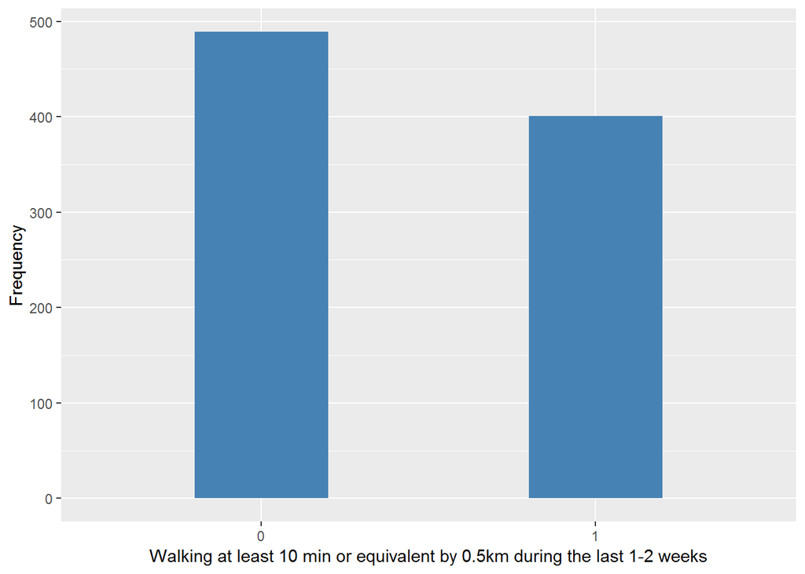

#### 2.7.2.4 Validation

|  | 0->0 | 1->1 |
| --- | --- | --- |
| BeforeH | 489 | 401 |
| AfterH | 489 | 401 |

## 2.8 Rural Peru

### 2.8.1 Wave 1

#### 2.8.1.1 Study-specific variable description

| **Name** | `PWALKANY` |
| --- | --- |
| **Label** | `walk of 0.5 kilometre in last month?` |
| **Table name** | `1066-RuralPeru-Baseline` |
| **Categories:** | `0 = No` `1 = Yes` |
| **Missings:** | `NA` |
| **Description** |  |

PWALKANY

| Sample size | Missing values |
| --- | --- |
| 552 | 2 |

Category

|  | 0 | 1 |
| --- | --- | --- |
| Frequency | 219.00 | 331.00 |
| Percentage | 39.67 | 59.96 |

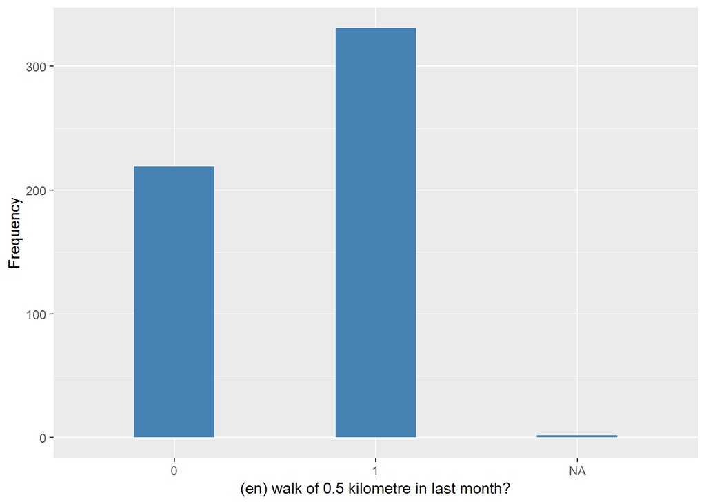

#### 2.8.1.2 Harmonisation algorithm

To compute the harmonize variable from the study-specific variable it has to be recoded as follows:

- `NA into 999`

```r
t1066_ds_RP_w1 <- tibble(id = t1066_RP_w1$id)
t1066_ds_RP_w1$t_walks <- Recode(t1066_RP_w1$PWALKANY, "NA = '999' ")
t1066_ds_RP_w1$t_walks <- labelled(t1066_ds_RP_w1$t_walks, labels = c(Missing = 999,
    Do_not_know = 998, Refuse = 997, Not_applicable = 996, Does_not_answer = 995,
    Not_attempt_not_done = 994, Disable_to_measure = 993, Impute = 992, CAPI_interviewer_error = 991))
```

#### 2.8.1.3 Statistical description of the new harmonised variable

Walking at least 10 min or equivalent by 0.5km during the last 1-2 weeks

| Sample size | Missing values |
| --- | --- |
| 552 | 2 |

Category

|  | 0 | 1 |
| --- | --- | --- |
| Frequency | 219.00 | 331.00 |
| Percentage | 39.67 | 59.96 |

Type of missing

|  | 991 | 992 | 993 | 994 | 995 | 996 | 997 | 998 | 999 | NA |
| --- | --- | --- | --- | --- | --- | --- | --- | --- | --- | --- |
| Frequency | 0 | 0 | 0 | 0 | 0 | 0 | 0 | 0 | 2.00 | 0 |
| Percentage | 0 | 0 | 0 | 0 | 0 | 0 | 0 | 0 | 0.36 | 0 |

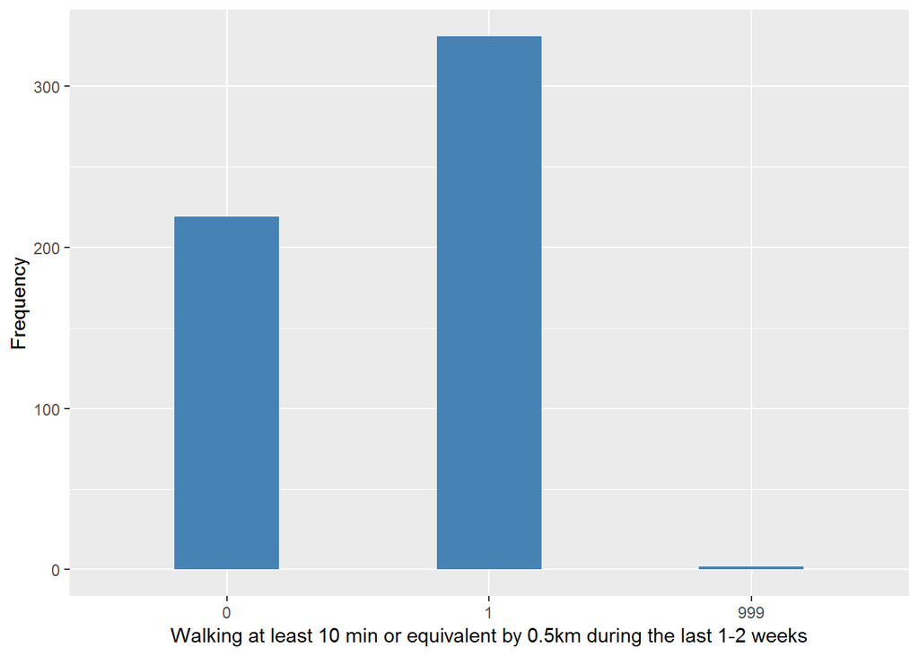

#### 2.8.1.4 Validation

|  | 0->0 | 1->1 | NA->999 |
| --- | --- | --- | --- |
| BeforeH | 219 | 331 | 2 |
| AfterH | 219 | 331 | 2 |

### 2.8.2 Wave 2

#### 2.8.2.1 Study-specific variable description

| **Name** | `f_PWALKANY` |
| --- | --- |
| **Label** | `walk of 0.5 kilometre in last month?` |
| **Table name** | `1066-RuralPeru-Followup` |
| **Categories:** | `0 = No` `1 = Yes` |
| **Missings:** |  |
| **Description** |  |

f_PWALKANY

| Sample size | Missing values |
| --- | --- |
| 421 | 0 |

Category

|  | 0 | 1 |
| --- | --- | --- |
| Frequency | 273.00 | 148.00 |
| Percentage | 64.85 | 35.15 |

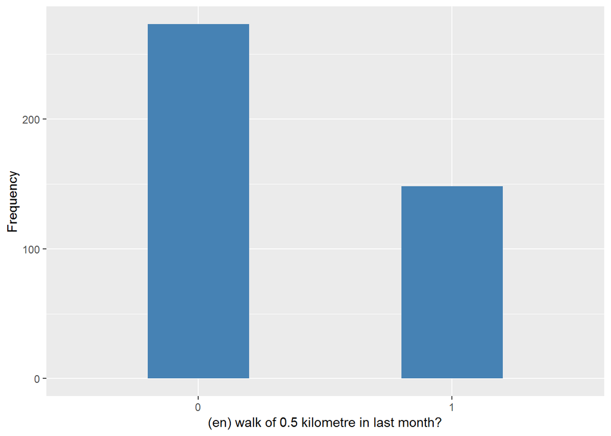

#### 2.8.2.2 Harmonisation algorithm

To compute the harmonize variable from the study-specific variable it has to be recoded as follows:

- `NA into 999`

```r
t1066_ds_RP_w2 <- tibble(id = t1066_RP_w2$id)
t1066_ds_RP_w2$t_walks <- Recode(t1066_RP_w2$f_PWALKANY, "NA = '999' ")
t1066_ds_RP_w2$t_walks <- labelled(t1066_ds_RP_w2$t_walks, labels = c(Missing = 999,
    Do_not_know = 998, Refuse = 997, Not_applicable = 996, Does_not_answer = 995,
    Not_attempt_not_done = 994, Disable_to_measure = 993, Impute = 992, CAPI_interviewer_error = 991))
```

#### 2.8.2.3 Statistical description of the new harmonised variable

Walking at least 10 min or equivalent by 0.5km during the last 1-2 weeks

| Sample size | Missing values |
| --- | --- |
| 421 | 0 |

Category

|  | 0 | 1 |
| --- | --- | --- |
| Frequency | 273.00 | 148.00 |
| Percentage | 64.85 | 35.15 |

Type of missing

|  | 991 | 992 | 993 | 994 | 995 | 996 | 997 | 998 | 999 | NA |
| --- | --- | --- | --- | --- | --- | --- | --- | --- | --- | --- |
| Frequency | 0 | 0 | 0 | 0 | 0 | 0 | 0 | 0 | 0 | 0 |
| Percentage | 0 | 0 | 0 | 0 | 0 | 0 | 0 | 0 | 0 | 0 |

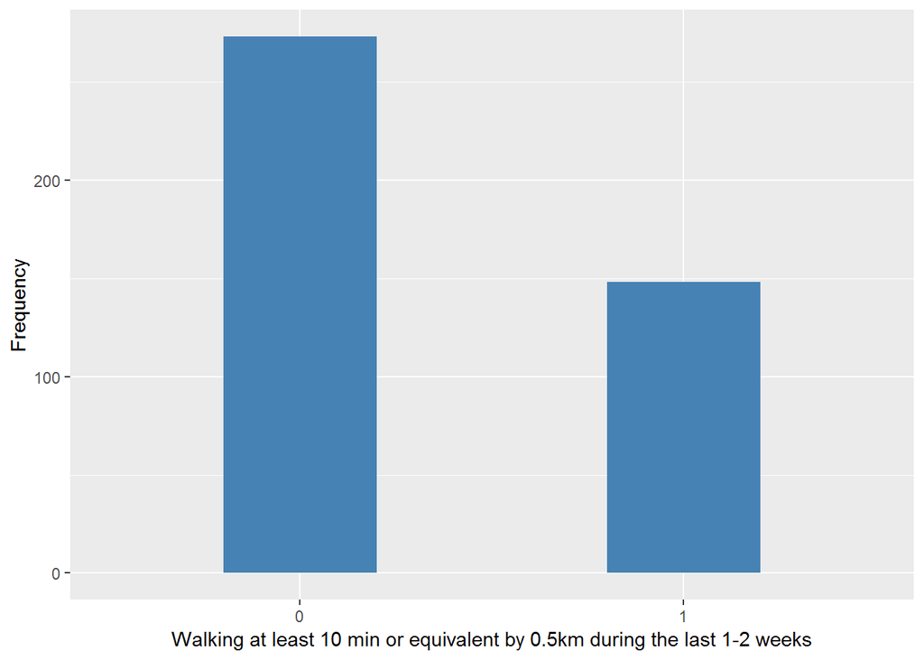

#### 2.8.2.4 Validation

|  | 0->0 | 1->1 |
| --- | --- | --- |
| BeforeH | 273 | 148 |
| AfterH | 273 | 148 |

## 2.9 Urban Mexico

### 2.9.1 Wave 1

#### 2.9.1.1 Study-specific variable description

| **Name** | `PWALKANY` |
| --- | --- |
| **Label** | `walk of 0.5 kilometre in last month?` |
| **Table name** | `1066-UrbanMexico-Baseline` |
| **Categories:** | `0 = No` `1 = Yes` |
| **Missings:** | `NA` |
| **Description** |  |

PWALKANY

| Sample size | Missing values |
| --- | --- |
| 1003 | 7 |

Category

|  | 0 | 1 |
| --- | --- | --- |
| Frequency | 383.00 | 613.00 |
| Percentage | 38.19 | 61.12 |

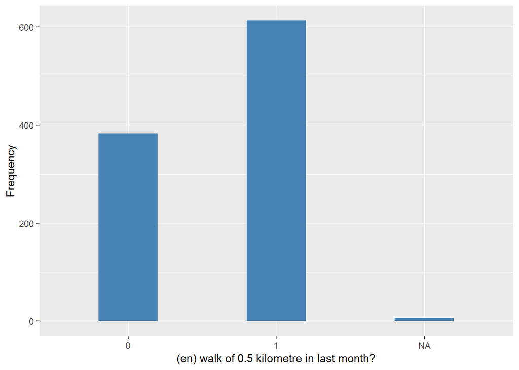

#### 2.9.1.2 Harmonisation algorithm

To compute the harmonize variable from the study-specific variable it has to be recoded as follows:

- `NA into 999`

```r
t1066_ds_UM_w1 <- tibble(id = t1066_UM_w1$id)
t1066_ds_UM_w1$t_walks <- Recode(t1066_UM_w1$PWALKANY, "NA = '999' ")
t1066_ds_UM_w1$t_walks <- labelled(t1066_ds_UM_w1$t_walks, labels = c(Missing = 999,
    Do_not_know = 998, Refuse = 997, Not_applicable = 996, Does_not_answer = 995,
    Not_attempt_not_done = 994, Disable_to_measure = 993, Impute = 992, CAPI_interviewer_error = 991))
```

#### 2.9.1.3 Statistical description of the new harmonised variable

Walking at least 10 min or equivalent by 0.5km during the last 1-2 weeks

| Sample size | Missing values |
| --- | --- |
| 1003 | 7 |

Category

|  | 0 | 1 |
| --- | --- | --- |
| Frequency | 383.00 | 613.00 |
| Percentage | 38.19 | 61.12 |

Type of missing

|  | 991 | 992 | 993 | 994 | 995 | 996 | 997 | 998 | 999 | NA |
| --- | --- | --- | --- | --- | --- | --- | --- | --- | --- | --- |
| Frequency | 0 | 0 | 0 | 0 | 0 | 0 | 0 | 0 | 7.0 | 0 |
| Percentage | 0 | 0 | 0 | 0 | 0 | 0 | 0 | 0 | 0.7 | 0 |

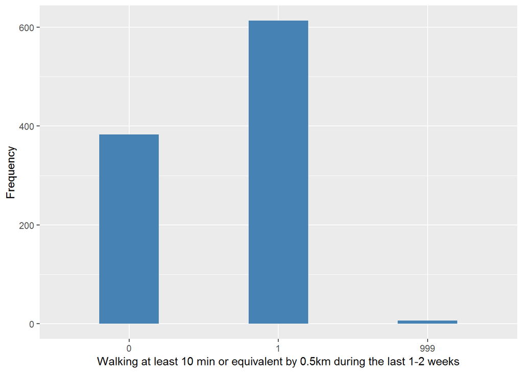

#### 2.9.1.4 Validation

|  | 0->0 | 1->1 | NA->999 |
| --- | --- | --- | --- |
| BeforeH | 383 | 613 | 7 |
| AfterH | 383 | 613 | 7 |